# Google DA Capstone Project Analyses

First, I initiated the packages I thought I would need to run the analyses. The two I frequently run right at the top are `tidyverse` and `ggplot2`. If there are others in the code block, that’s because I added them while conducting my analyses.

```r
library(tidyverse)
```

```r
library(ggplot2)
library(readxl)
```

Next, I loaded the data from the CSV files I created in BigQuery.

```r
setwd("C:/Users/barre/OneDrive/01 Projects/Google Data Analytics Course 2023/Course-08--Capstone-project/Google-DA-capstone-project")
daily_data <- read_csv('C:/Users/barre/OneDrive/01 Projects/Google Data Analytics Course 2023/Course-08--Capstone-project/Google-DA-capstone-project/Combined-Files-(Minute-Hour-Day)/Day-combined.csv')
hourly_data <- read_csv("C:/Users/barre/OneDrive/01 Projects/Google Data Analytics Course 2023/Course-08--Capstone-project/Google-DA-capstone-project/Combined-Files-(Minute-Hour-Day)/Hourly-combined.csv")
minute_data <- read_csv("C:/Users/barre/OneDrive/01 Projects/Google Data Analytics Course 2023/Course-08--Capstone-project/Google-DA-capstone-project/Combined-Files-(Minute-Hour-Day)/Minute-combined.csv")
```

As I worked with the data, I noticed that R was treating the ID numbers as numbers rather than text. So, I changed the data type of the ID columns.

```r
daily_data$Id <- as.character(daily_data$Id)
hourly_data$ID <- as.character(hourly_data$ID)
minute_data$ID <- as.character(minute_data$ID)
```

I wanted to get a sense about whether the people that participated in the study were active or not, so I decided to summarize data about active minutes.

```r
daily_summary_all <- daily_data %>%
  group_by(Id) %>%
  summarize(MeanActivity = mean(LightlyActiveMinutes + FairlyActiveMinutes +
                                  VeryActiveMinutes),
            MinActivity = min(LightlyActiveMinutes + FairlyActiveMinutes +
                                VeryActiveMinutes),
            FirstQActivity = quantile((LightlyActiveMinutes +
                                         FairlyActiveMinutes +
                                         VeryActiveMinutes), probs = 0.25,
                                      names = FALSE),
            MedianActivity = median(LightlyActiveMinutes +
                                      FairlyActiveMinutes + VeryActiveMinutes),
            ThirdQActivity = quantile((LightlyActiveMinutes +
                                         FairlyActiveMinutes +
                                         VeryActiveMinutes), probs = 0.75,
                                      names = FALSE),
            MaxActivity = max(LightlyActiveMinutes + FairlyActiveMinutes +
                                VeryActiveMinutes))
arrange(daily_summary_all, MeanActivity)
```

```
## # A tibble: 24 × 7
##    Id      MeanActivity MinActivity FirstQActivity MedianActivity ThirdQActivity
##    <chr>          <dbl>       <dbl>          <dbl>          <dbl>          <dbl>
##  1 192797…          85           32            51             55             95
##  2 677588…         107           58            89            120            132.
##  3 184450…         147.          82           129            176            180
##  4 879200…         178.          79           106.           129            250.
##  5 444511…         218.          58           190.           226.           246.
##  6 700774…         220          203           212.           220            228.
##  7 837856…         227.          93           178.           240.           276.
##  8 708636…         234           67           210.           236            265.
##  9 232012…         242          242           242            242            242
## 10 555395…         243.          46           214.           259            310
## # ℹ 14 more rows
## # ℹ 1 more variable: MaxActivity <dbl>
```

After reviewing the data, I began thinking that `LightlyActiveMinutes` was skewing the data, making it difficult to determine how much people exercise. (I thought that `LightlyActiveMinutes` could mean a walk from the living room to the kitchen, and not exercise time.) So, I ran the same calculations without `LightlyActiveMinutes`.

```r
daily_summary_active <- daily_data %>%
  group_by(Id) %>%
  summarize(MeanActivity = mean(FairlyActiveMinutes + VeryActiveMinutes),
            MinActivity = min(FairlyActiveMinutes + VeryActiveMinutes),
            FirstQActivity = quantile((FairlyActiveMinutes + VeryActiveMinutes),                                         probs = 0.25, names = FALSE),
            MedianActivity = median(FairlyActiveMinutes + VeryActiveMinutes),
            ThirdQActivity = quantile((FairlyActiveMinutes + VeryActiveMinutes),                                         probs = 0.75, names = FALSE),
            MaxActivity = max(FairlyActiveMinutes + VeryActiveMinutes))
arrange(daily_summary_active, MeanActivity)
```

```
## # A tibble: 24 × 7
##    Id      MeanActivity MinActivity FirstQActivity MedianActivity ThirdQActivity
##    <chr>          <dbl>       <dbl>          <dbl>          <dbl>          <dbl>
##  1 192797…        0               0              0              0            0
##  2 232012…        0               0              0              0            0
##  3 700774…        0               0              0              0            0
##  4 202635…        0.393           0              0              0            0
##  5 184450…        2.33            0              0              0            3.5
##  6 611766…        4.89            0              0              0            0
##  7 444511…        8.14            0              0              0            8
##  8 879200…        8.93            0              0              0           15
##  9 431970…       14.9             0              0             13           21
## 10 164443…       22               0              0              4           26
## # ℹ 14 more rows
## # ℹ 1 more variable: MaxActivity <dbl>
```

I used data from this data frame to make some observations about the type of person that would use a fitness tracker.

I also created a box-and-whisker plot of each participant’s activity. This plot didn’t make it into the presentation, so I didn’t add aesthetics here.

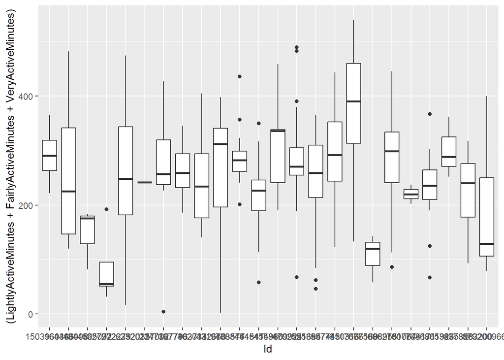

```r
ggplot(daily_data, aes(x = Id, y = (LightlyActiveMinutes + FairlyActiveMinutes +                                      VeryActiveMinutes))) +
  geom_boxplot(aes(group = Id))
```

I then created a stacked bar chart showing the various activity levels.

I was unable to stack the charts based on the length of the bars. (**Something to come back to later.**) So, I just left the plot as a horizontal bar chart without the additional organization. (Since this didn’t go in the presentation, I didn’t add descriptive elements to the plot.)

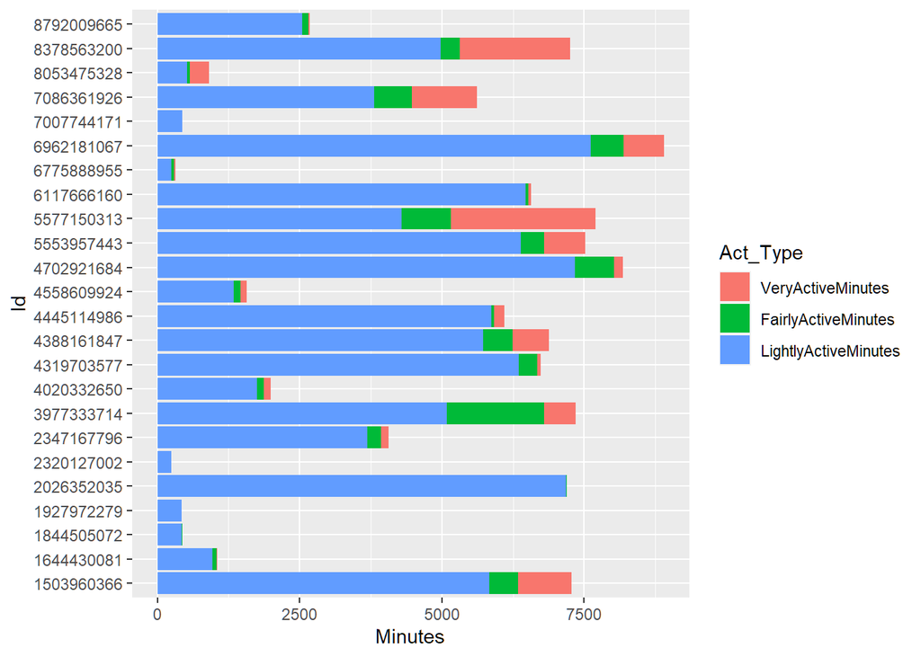

```r
temp_01 <- daily_data[, c("Id", "LightlyActiveMinutes",
                                 "FairlyActiveMinutes", "VeryActiveMinutes")]
temp_daily_act <- temp_01 %>%
  pivot_longer(cols = !Id, names_to = "Act_Type", values_to = "Minutes")
temp_daily_act$Act_Type <- factor(temp_daily_act$Act_Type, levels =
                                    c('VeryActiveMinutes',
                                      'FairlyActiveMinutes',
                                      'LightlyActiveMinutes'))
ggplot(temp_daily_act, aes(fill = Act_Type, y = Minutes, x = Id, minutes)) + geom_col(position = 'stack', stat = 'identity') + coord_flip()
```